# HW3

jessekim

11/8/2019

## Chapter 13

### 13.2.1

#### 1

```r
head(nycflights13::flights)
```

```
## # A tibble: 6 x 19
##    year month   day dep_time sched_dep_time dep_delay arr_time
##   <int> <int> <int>    <int>          <int>     <dbl>    <int>
## 1  2013     1     1      517            515         2      830
## 2  2013     1     1      533            529         4      850
## 3  2013     1     1      542            540         2      923
## 4  2013     1     1      544            545        -1     1004
## 5  2013     1     1      554            600        -6      812
## 6  2013     1     1      554            558        -4      740
## # … with 12 more variables: sched_arr_time <int>, arr_delay <dbl>,
## #   carrier <chr>, flight <int>, tailnum <chr>, origin <chr>, dest <chr>,
## #   air_time <dbl>, distance <dbl>, hour <dbl>, minute <dbl>,
## #   time_hour <dttm>
```

```r
head(nycflights13::airports)
```

```
## # A tibble: 6 x 8
##   faa   name                       lat   lon   alt    tz dst   tzone
##   <chr> <chr>                    <dbl> <dbl> <dbl> <dbl> <chr> <chr>
## 1 04G   Lansdowne Airport         41.1 -80.6  1044    -5 A     America/New…
## 2 06A   Moton Field Municipal A…  32.5 -85.7   264    -6 A     America/Chi…
## 3 06C   Schaumburg Regional       42.0 -88.1   801    -6 A     America/Chi…
## 4 06N   Randall Airport           41.4 -74.4   523    -5 A     America/New…
## 5 09J   Jekyll Island Airport     31.1 -81.4    11    -5 A     America/New…
## 6 0A9   Elizabethton Municipal …  36.4 -82.2  1593    -5 A     America/New…
```

```r
nycflights13::flights %>%
  left_join(
    nycflights13::airports,
    by = c("origin" = "faa")
  ) %>%
  left_join(
    nycflights13::airports,
    by = c("dest" = "faa"),
    suffix = c("_origin", "_dest")
  ) %>%
  select(
    year, month, day, sched_dep_time, origin, lat_origin, lon_origin, dest, lat_dest, lon_dest
  )
```

```
## # A tibble: 336,776 x 10
##     year month   day sched_dep_time origin lat_origin lon_origin dest
##    <int> <int> <int>          <int> <chr>       <dbl>      <dbl> <chr>
##  1  2013     1     1            515 EWR          40.7      -74.2 IAH
##  2  2013     1     1            529 LGA          40.8      -73.9 IAH
##  3  2013     1     1            540 JFK          40.6      -73.8 MIA
##  4  2013     1     1            545 JFK          40.6      -73.8 BQN
##  5  2013     1     1            600 LGA          40.8      -73.9 ATL
##  6  2013     1     1            558 EWR          40.7      -74.2 ORD
##  7  2013     1     1            600 EWR          40.7      -74.2 FLL
##  8  2013     1     1            600 LGA          40.8      -73.9 IAD
##  9  2013     1     1            600 JFK          40.6      -73.8 MCO
## 10  2013     1     1            600 LGA          40.8      -73.9 ORD
## # … with 336,766 more rows, and 2 more variables: lat_dest <dbl>,
## #   lon_dest <dbl>
```

> We can combine `flights` data with `airports` data, by `origin` and `dest` of `flights` equals to `faa` of `airports` data respectively. Then we can calculate the straight distance between `origin` and `dest` with latitude and longitude information.

### 13.3.1

#### 2

```r
Lahman::Batting %>%
  group_by(playerID, yearID, stint) %>%
  summarize(n = n()) %>%
  filter(n > 1)
```

```
## # A tibble: 0 x 4
## # Groups:   playerID, yearID [0]
## # … with 4 variables: playerID <chr>, yearID <int>, stint <int>, n <int>
```

> 1. Lahman::Batting: (`playerID`, `yearID`, `stint`)

```r
babynames::babynames %>%
  group_by(year, sex, name) %>%
  summarize(n = n()) %>%
  filter(n > 1)
```

```
## # A tibble: 0 x 4
## # Groups:   year, sex [0]
## # … with 4 variables: year <dbl>, sex <chr>, name <chr>, n <int>
```

> 2. babynames::babynames: (`year`, `sex`, `name`)

```r
nasaweather::atmos
```

```
## # A tibble: 41,472 x 11
##      lat  long  year month surftemp  temp pressure ozone cloudlow cloudmid
##    <dbl> <dbl> <int> <int>    <dbl> <dbl>    <dbl> <dbl>    <dbl>    <dbl>
##  1  36.2 -114.  1995     1     273.  272.      835   304      7.5     34.5
##  2  33.7 -114.  1995     1     280.  282.      940   304     11.5     32.5
##  3  31.2 -114.  1995     1     285.  285.      960   298     16.5     26
##  4  28.7 -114.  1995     1     289.  291.      990   276     20.5     14.5
##  5  26.2 -114.  1995     1     292.  293.     1000   274     26       10.5
##  6  23.7 -114.  1995     1     294.  294.     1000   264     30        9.5
##  7  21.2 -114.  1995     1     295   295.     1000   258     29.5     11
##  8  18.7 -114.  1995     1     298.  297.     1000   252     26.5     17.5
##  9  16.2 -114.  1995     1     300.  298.     1000   250     27.5     18.5
## 10  13.7 -114.  1995     1     300.  299.     1000   250     26       16.5
## # … with 41,462 more rows, and 1 more variable: cloudhigh <dbl>
```

```r
nasaweather::atmos %>%
  group_by(lat, long, year, month) %>%
  summarize(n = n()) %>%
  filter(n > 1)
```

```
## # A tibble: 0 x 5
## # Groups:   lat, long, year [0]
## # … with 5 variables: lat <dbl>, long <dbl>, year <int>, month <int>,
## #   n <int>
```

> 3. (`lat`, `long`, `year`, `month`)

```r
fueleconomy::vehicles %>%
  group_by(id) %>%
  summarize(n = n()) %>%
  filter(n > 1)
```

```
## # A tibble: 0 x 2
## # … with 2 variables: id <int>, n <int>
```

> 4. (`id`)

```r
ggplot2::diamonds %>%
  group_by(carat, cut, color, clarity, depth, table, price, x, y, z) %>%
  summarize(n = n()) %>%
  filter(n > 1)
```

```
## # A tibble: 143 x 11
## # Groups:   carat, cut, color, clarity, depth, table, price, x, y [143]
##    carat cut       color clarity depth table price     x     y     z     n
##    <dbl> <ord>     <ord> <ord>   <dbl> <dbl> <int> <dbl> <dbl> <dbl> <int>
##  1  0.3  Good      J     VS1      63.4    57   394  4.23  4.26  2.69     2
##  2  0.3  Very Good G     VS2      63      55   526  4.29  4.31  2.71     2
##  3  0.3  Very Good J     VS1      63.4    57   506  4.26  4.23  2.69     2
##  4  0.3  Premium   D     SI1      62.2    58   709  4.31  4.28  2.67     2
##  5  0.3  Ideal     G     VS2      63      55   675  4.31  4.29  2.71     2
##  6  0.3  Ideal     G     IF       62.1    55   863  4.32  4.35  2.69     2
##  7  0.3  Ideal     H     SI1      62.2    57   450  4.26  4.29  2.66     2
##  8  0.3  Ideal     H     SI1      62.2    57   450  4.27  4.28  2.66     2
##  9  0.31 Good      D     SI1      63.5    56   571  4.29  4.31  2.73     2
## 10  0.31 Very Good D     SI1      63.5    56   732  4.31  4.29  2.73     2
## # … with 133 more rows
```

> No key

### 13.4.6

#### 3

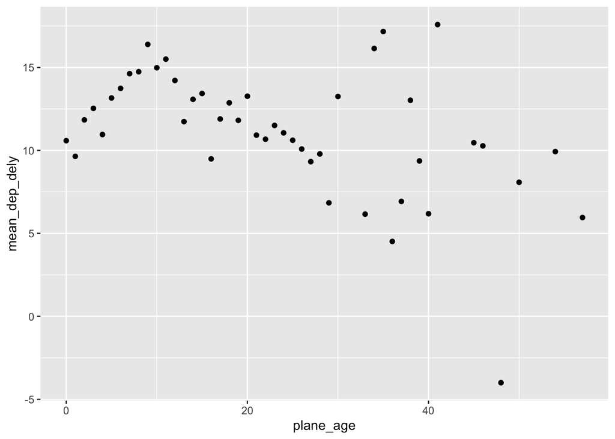

```r
nycflights13::flights %>%
  left_join(
    nycflights13::planes,
    by = c("tailnum" = "tailnum"),
    suffix = c("", "_planes")
  ) %>%
  mutate(
    plane_age = year - year_planes
  ) %>%
  group_by(plane_age) %>%
  summarize(
    mean_dep_dely = mean(dep_delay, na.rm = TRUE)
  ) %>%
  ggplot(aes(plane_age, mean_dep_dely)) +
  geom_point(na.rm = TRUE)
```

### 13.5.1

#### 1

```r
nycflights13::flights %>%
  filter(is.na(tailnum))
```

```
## # A tibble: 2,512 x 19
##     year month   day dep_time sched_dep_time dep_delay arr_time
##    <int> <int> <int>    <int>          <int>     <dbl>    <int>
##  1  2013     1     2       NA           1545        NA       NA
##  2  2013     1     2       NA           1601        NA       NA
##  3  2013     1     3       NA            857        NA       NA
##  4  2013     1     3       NA            645        NA       NA
##  5  2013     1     4       NA            845        NA       NA
##  6  2013     1     4       NA           1830        NA       NA
##  7  2013     1     5       NA            840        NA       NA
##  8  2013     1     7       NA            820        NA       NA
##  9  2013     1     8       NA           1645        NA       NA
## 10  2013     1     9       NA            755        NA       NA
## # … with 2,502 more rows, and 12 more variables: sched_arr_time <int>,
## #   arr_delay <dbl>, carrier <chr>, flight <int>, tailnum <chr>,
## #   origin <chr>, dest <chr>, air_time <dbl>, distance <dbl>, hour <dbl>,
## #   minute <dbl>, time_hour <dttm>
```

> Flights that don’t have `tailnum` also do not have `dep_time` and `arr_time`. It means that the flight has been cancelled.

```r
nycflights13::flights %>%
  anti_join(
    nycflights13::planes,
    by = "tailnum"
  ) %>%
  group_by(carrier) %>%
  summarize(n = n()) %>%
  arrange(-n)
```

```
## # A tibble: 10 x 2
##    carrier     n
##    <chr>   <int>
##  1 MQ      25397
##  2 AA      22558
##  3 UA       1693
##  4 9E       1044
##  5 B6        830
##  6 US        699
##  7 FL        187
##  8 DL        110
##  9 F9         50
## 10 WN         38
```

> The `carrier` of the flights is one of `MQ` or `AA` mostly.

## Chapter 14

### 14.2.5

#### 2

```r
ironman <- c("I", "am", "iron", "man")
count <- c("1", "2", "3", "4")

str_c(ironman)
```

```
## [1] "I"    "am"   "iron" "man"
```

```r
str_c(count, ironman, sep = ", ")
```

```
## [1] "1, I"    "2, am"   "3, iron" "4, man"
```

```r
str_c(count, ironman, collapse = ", ")
```

```
## [1] "1I, 2am, 3iron, 4man"
```

> `sep` argument is used when combining two string vectors into single string vector, inserted between the matching vectors.

> `collapse` argument is used when combining a string vector into string data, inserted between each element of the vector.

### 14.3.1.1

#### 1

> To express / as a charactor in R, we need to escape the charactor like “//”. However, to express / as a charactor in R, we need to escape the charactor agian as “//”. So we need two ’/’s that regex can understand, and as / for regex is expressed as “//” for R, the expression becomes “////”.

### 14.3.2.1

#### 2

```r
# 1.
str_view(stringr::words, "^y", match = TRUE)
```

[interactive chart not shown]

```r
# 2.
str_view(stringr::words, "x$", match = TRUE)
```

[interactive chart not shown]

```r
# 3.
str_view(stringr::words, "^...$", match = TRUE)
```

[interactive chart not shown]

```r
# 4.
str_view(stringr::words, ".{7,}", match = TRUE)
```

[interactive chart not shown]

### 14.3.3.1

#### 3

```r
str_view(stringr::words, "q[^u]", match = TRUE)
```

[interactive chart not shown]

> Yes. “q” is always followed by “u” in the data.

### 14.3.4.1

#### 3

```r
# 1.
str_view(stringr::words, "^[^aeiou]{3}", match = TRUE)
```

[interactive chart not shown]

```r
# 2.
str_view(stringr::words, "[aeiou]{3,}", match = TRUE)
```

[interactive chart not shown]

```r
# 3.
str_view(stringr::words, "([aeiou][^aeiou]){2,}", match = TRUE)
```

[interactive chart not shown]

### 14.3.5.1

#### 2

```r
# 1.
str_view(stringr::words, "^(.)($|.*\\1$)", match = TRUE)
```

[interactive chart not shown]

```r
# 2.
str_view(stringr::words, "(..).*\\1", match = TRUE)
```

[interactive chart not shown]

```r
# 3.
str_view(stringr::words, "(.).*\\1.*\\1", match = TRUE)
```

[interactive chart not shown]

### 14.4.1.1

#### 2

```r
word_vowels <- tibble(
  word = stringr::words
  ) %>%
  mutate(
    vowels = str_count(word, "[aeiou]"),
    length = str_length(word),
    vowel_prop = vowels/length
  )
```

```r
word_vowels %>% arrange(-vowels) %>% filter(vowels == max(vowels))
```

```
## # A tibble: 8 x 4
##   word        vowels length vowel_prop
##   <chr>        <int>  <int>      <dbl>
## 1 appropriate      5     11      0.455
## 2 associate        5      9      0.556
## 3 available        5      9      0.556
## 4 colleague        5      9      0.556
## 5 encourage        5      9      0.556
## 6 experience       5     10      0.5
## 7 individual       5     10      0.5
## 8 television       5     10      0.5
```

> These words has the highest number of vowels with 5.

```r
word_vowels %>% arrange(-vowel_prop)
```

```
## # A tibble: 980 x 4
##    word   vowels length vowel_prop
##    <chr>   <int>  <int>      <dbl>
##  1 a           1      1      1
##  2 area        3      4      0.75
##  3 idea        3      4      0.75
##  4 age         2      3      0.667
##  5 ago         2      3      0.667
##  6 air         2      3      0.667
##  7 die         2      3      0.667
##  8 due         2      3      0.667
##  9 eat         2      3      0.667
## 10 europe      4      6      0.667
## # … with 970 more rows
```

> “a” has the highest propportion of vowels with 1.

### 14.4.2.1

#### 1

```r
colours <- c("red", "orange", "yellow", "green", "blue", "purple")
(colour_match <- str_c("( ", colours, "|", colours, " )", collapse = "|"))
```

```
## [1] "( red|red )|( orange|orange )|( yellow|yellow )|( green|green )|( blue|blue )|( purple|purple )"
```

```r
sentences[str_count(sentences, colour_match) > 1]
```

```
## [1] "It is hard to erase blue or red ink."
## [2] "The sky in the west is tinged with orange red."
```

> Filter the word only with whitespace following or followed.

### 14.4.3.1

#### 1

```r
numbers <- c("one", "two", "three", "four", "five", "six", "seven", "eight", "nine", "ten", "eleven", "twelve")
number_match <- str_c("\\b(", str_c(numbers, collapse = "|"), ") [^ |.]{1,}", sep = "")

stringr::sentences[!is.na(str_extract(stringr::sentences, number_match))] %>%
  str_extract(number_match)
```

```
##  [1] "seven books"   "two met"       "two factors"   "three lists"
##  [5] "seven is"      "two when"      "ten inches"    "one war"
##  [9] "one button"    "six minutes"   "ten years"     "two shares"
## [13] "two distinct"  "five cents"    "two pins"      "five robins"
## [17] "four kinds"    "three story"   "three inches"  "six comes"
## [21] "three batches" "two leaves"
```

### 14.4.4.1

#### 3

```r
str_replace(stringr::words, "(.)(.*)(.)", "\\3\\2\\1") %>%
  intersect(stringr::words)
```

```
##  [1] "a"          "america"    "area"       "dad"        "dead"
##  [6] "lead"       "read"       "depend"     "god"        "educate"
## [11] "else"       "encourage"  "engine"     "europe"     "evidence"
## [16] "example"    "excuse"     "exercise"   "expense"    "experience"
## [21] "eye"        "dog"        "health"     "high"       "knock"
## [26] "deal"       "level"      "local"      "nation"     "on"
## [31] "non"        "no"         "rather"     "dear"       "refer"
## [36] "remember"   "serious"    "stairs"     "test"       "tonight"
## [41] "transport"  "treat"      "trust"      "window"     "yesterday"
```

### 14.4.5.1

#### 1

```r
str_split("apples, pears, and bananas", "(, |and ){1,}")
```

```
## [[1]]
## [1] "apples"  "pears"   "bananas"
```

## Chapter 15

### 15.3.1

#### 1

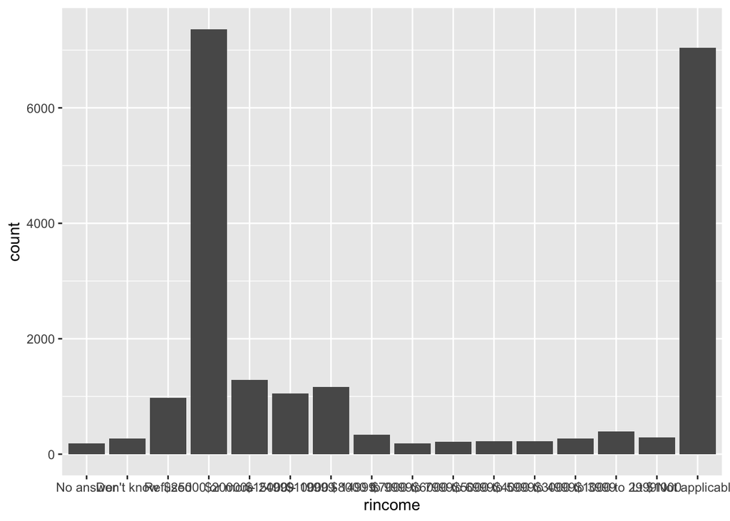

```r
gss_cat %>%
  ggplot(aes(rincome)) +
  geom_bar()
```

> There are too many values that the value label of x-axis is impossible to see. We can rotate the label of x-axis. Reference: https://www.datanovia.com/en/blog/ggplot-axis-ticks-set-and-rotate-text-labels/

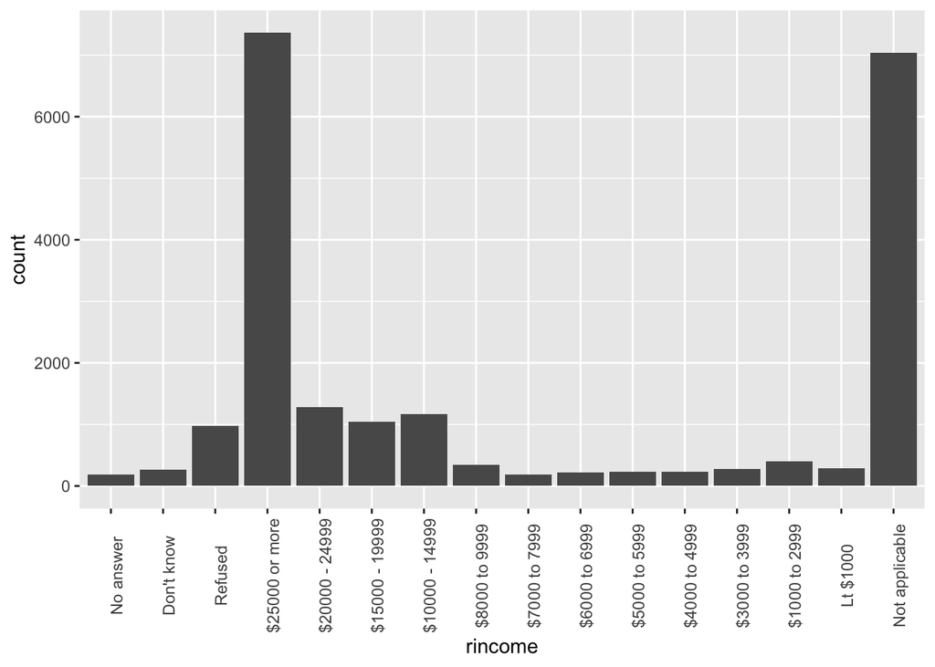

```r
gss_cat %>%
  ggplot(aes(rincome)) +
  geom_bar() +
  theme(axis.text.x = element_text(angle = 90))
```

### 15.4.1

#### 2

```r
factors <- c()

for (i in 1:length(gss_cat)) {
  if (is.factor(gss_cat[[i]])) {
    factors <- c(factors, i)
  }
}

colnames(gss_cat[factors])
```

```
## [1] "marital" "race"    "rincome" "partyid" "relig"   "denom"
```

> These are the factors of `gss_cat`.

```
## Factor: marital
## [1] "No answer"     "Never married" "Separated"     "Divorced"
## [5] "Widowed"       "Married"
```

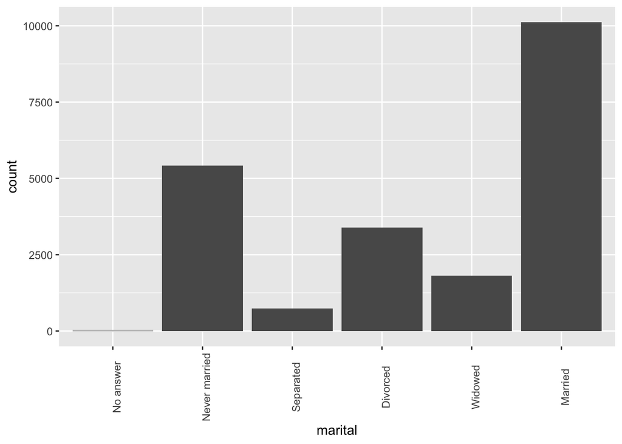

```
## Factor: race
## [1] "Other"          "Black"          "White"          "Not applicable"
```

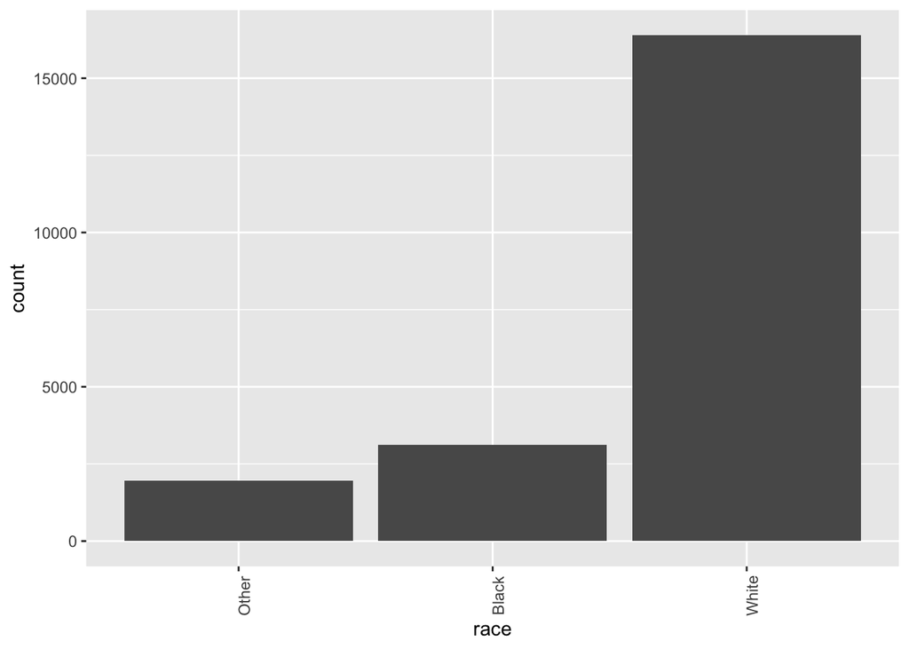

```
## Factor: rincome
##  [1] "No answer"      "Don't know"     "Refused"        "$25000 or more"
##  [5] "$20000 - 24999" "$15000 - 19999" "$10000 - 14999" "$8000 to 9999"
##  [9] "$7000 to 7999"  "$6000 to 6999"  "$5000 to 5999"  "$4000 to 4999"
## [13] "$3000 to 3999"  "$1000 to 2999"  "Lt $1000"       "Not applicable"
```

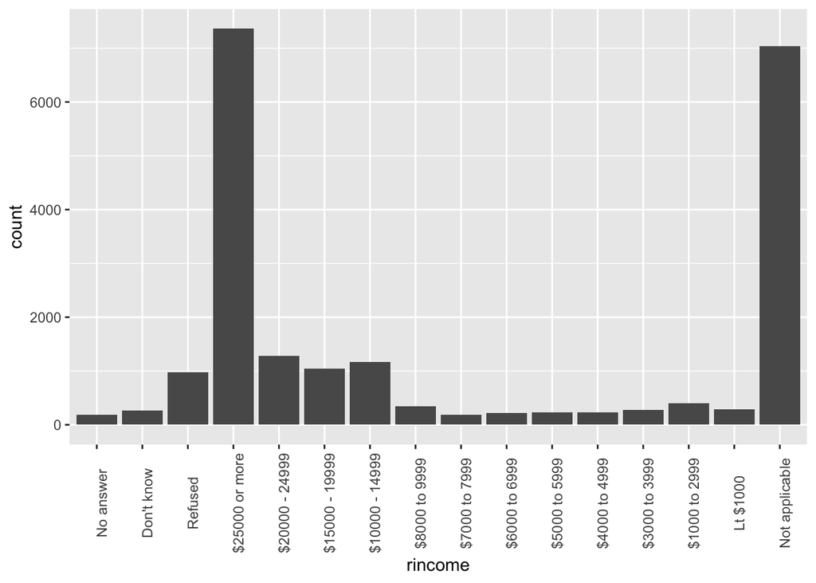

```
## Factor: partyid
##  [1] "No answer"          "Don't know"         "Other party"
##  [4] "Strong republican"  "Not str republican" "Ind,near rep"
##  [7] "Independent"        "Ind,near dem"       "Not str democrat"
## [10] "Strong democrat"
```

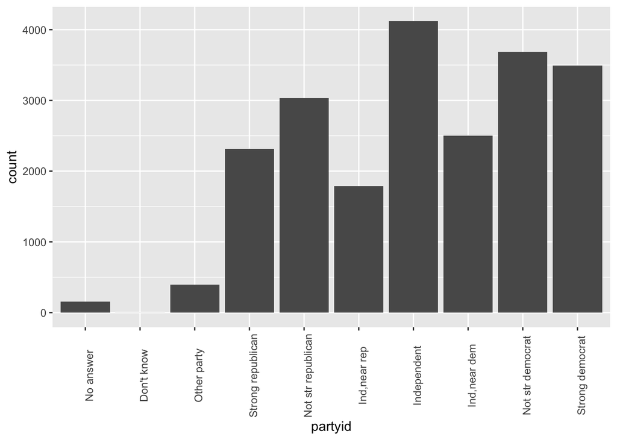

```
## Factor: relig
##  [1] "No answer"               "Don't know"
##  [3] "Inter-nondenominational" "Native american"
##  [5] "Christian"               "Orthodox-christian"
##  [7] "Moslem/islam"            "Other eastern"
##  [9] "Hinduism"                "Buddhism"
## [11] "Other"                   "None"
## [13] "Jewish"                  "Catholic"
## [15] "Protestant"              "Not applicable"
```

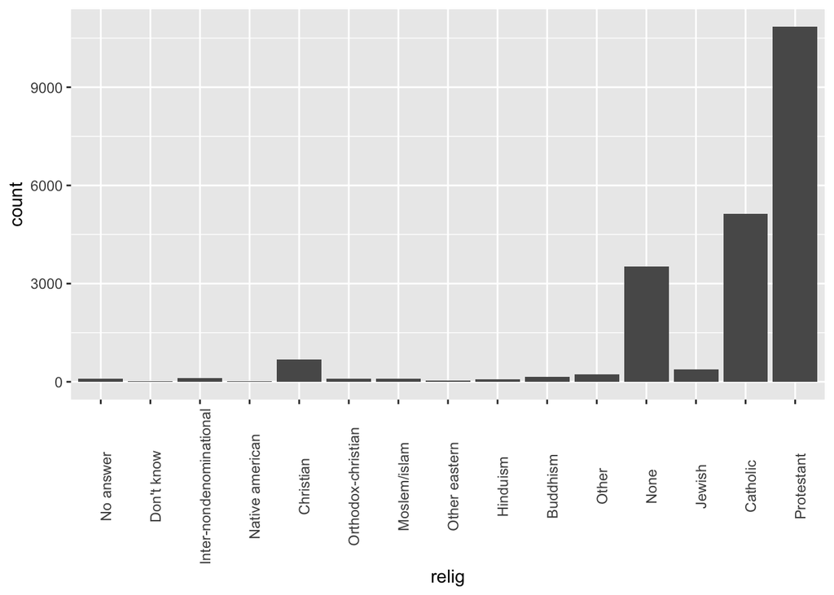

```
## Factor: denom
##  [1] "No answer"            "Don't know"           "No denomination"
##  [4] "Other"                "Episcopal"            "Presbyterian-dk wh"
##  [7] "Presbyterian, merged" "Other presbyterian"   "United pres ch in us"
## [10] "Presbyterian c in us" "Lutheran-dk which"    "Evangelical luth"
## [13] "Other lutheran"       "Wi evan luth synod"   "Lutheran-mo synod"
## [16] "Luth ch in america"   "Am lutheran"          "Methodist-dk which"
## [19] "Other methodist"      "United methodist"     "Afr meth ep zion"
## [22] "Afr meth episcopal"   "Baptist-dk which"     "Other baptists"
## [25] "Southern baptist"     "Nat bapt conv usa"    "Nat bapt conv of am"
## [28] "Am bapt ch in usa"    "Am baptist asso"      "Not applicable"
```

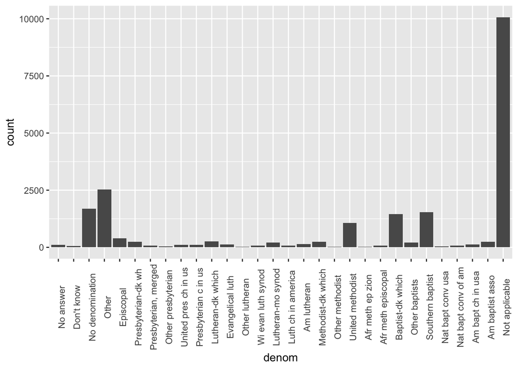

```r
for (i in factors) {
  colname <- colnames(gss_cat[i])
  cat("Factor:", colname, "\n")
  print(levels(gss_cat[[i]]))
  cat("\n")

  print(
    ggplot(gss_cat, aes(get(colname))) +
      geom_bar() +
      ggplot2::xlab(label = colname) +
      theme(axis.text.x = element_text(angle = 90))
  )
}
```

> `rincome`, `partyid` are principled by its order of the value. Other factors seem to have no strict priciple.

### 15.5.1

#### 1

```r
gss_party <- gss_cat %>%
  mutate(
    party = fct_recode(
      partyid,
      "Democrat" = "Strong democrat",
      "Democrat" = "Not str democrat",
      "Independent" = "Ind,near dem",
      "Independent" = "Ind,near rep",
      "Republican" = "Not str republican",
      "Republican" = "Strong republican"
    )
  ) %>%
  group_by(year, party) %>%
  summarize(n = n()) %>%
  spread(party, n) %>%
  mutate(
    n = sum(`No answer`, `Don't know`, `Other party`, `Republican`, `Independent`, `Democrat`, na.rm=TRUE)
  ) %>%
  transmute(
    Republican = Republican/n,
    Independent = Independent/n,
    Democrat = Democrat/n
  )

gss_party
```

```
## # A tibble: 8 x 4
## # Groups:   year [8]
##    year Republican Independent Democrat
##   <int>      <dbl>       <dbl>    <dbl>
## 1  2000      0.243       0.409    0.327
## 2  2002      0.276       0.359    0.334
## 3  2004      0.292       0.352    0.341
## 4  2006      0.251       0.410    0.318
## 5  2008      0.250       0.369    0.356
## 6  2010      0.226       0.402    0.341
## 7  2012      0.224       0.388    0.354
## 8  2014      0.212       0.429    0.325
```

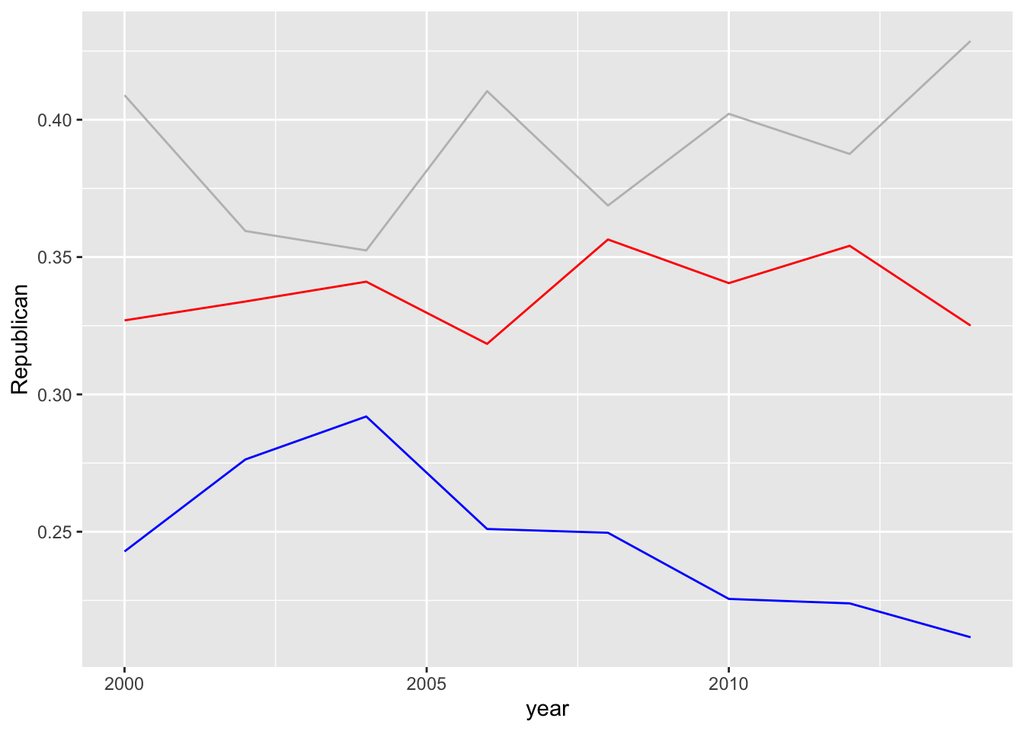

```r
gss_party %>%
  ggplot(aes(x = year)) +
  geom_line(aes(y = Republican), color="blue") +
  geom_line(aes(y = Independent), color="grey") +
  geom_line(aes(y = Democrat), color="red")
```

### 16.2.4

#### 2

```r
today(tzone = "GMT")
```

```
## [1] "2019-11-10"
```

```r
today(tzone = "Asia/Seoul")
```

```
## [1] "2019-11-10"
```

> `tzone` argument sets timezone we would like to get the current date from. When timezone is not correctly set, you can be using the date of another timezone, which would lead to misleading results.

### 16.3.4

#### 6

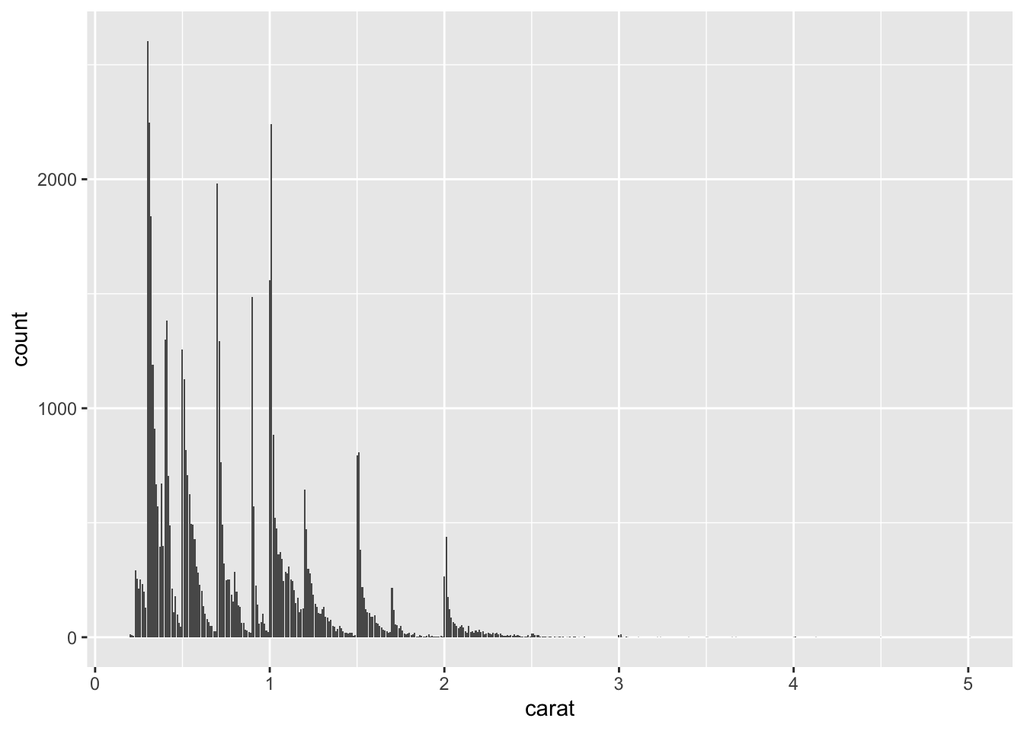

```r
ggplot(diamonds, aes(carat)) + geom_bar()
```

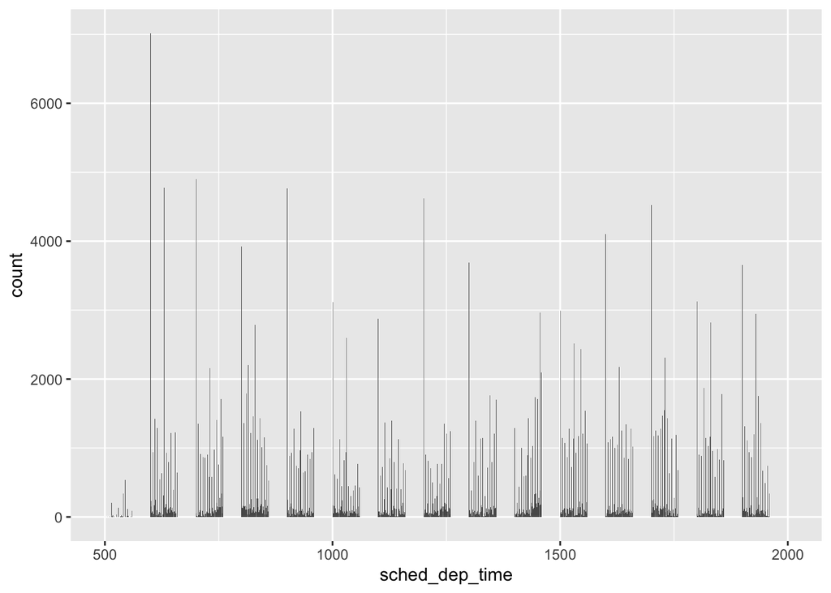

```r
ggplot(nycflights13::flights, aes(sched_dep_time)) + geom_bar(na.rm = TRUE) + ggplot2::xlim(c(500, 2000))
```

> They similarly suffer from the rounding bias. Maybe recorders tend to round the values to familiar numbers like 0, 1, 5, 10, 15, 20, and so on.

### 16.4.5

#### 4

```r
birthdate_to_age <- function (birthdate) {
  year(today()) - year(birthdate) + 1
}

birthdate_to_age(as_date("1994-05-14"))
```

```
## [1] 26
```